# Megacephalus - *Campylobacter jejuni*

–A user-friendly interface for gene expression analysis on different *Campylobacter jejuni* morphotypes (Spiral VS Filamentous).–

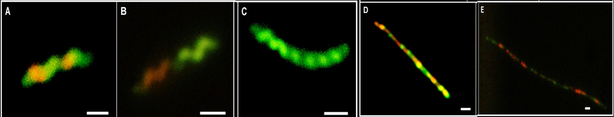

# 1 - Research statement

## 1.1 - Background

The varying morphotype of bacteria encompasses distinct transcriptomic profiles. Our group has collated 51 experiments of varying morphotypes in *Campylobacter jejuni* (*C.jejuni*) and analyzed their associated differentially expressed genes.

## 1.2 - Research question

We intend to explore the difference in expression of possible virulence factors and pathways that could promote the survival of *C.jejuni* across different morphotypes.

# 2 - Methodology

A brief outline of the revised methodology is illustrated here:

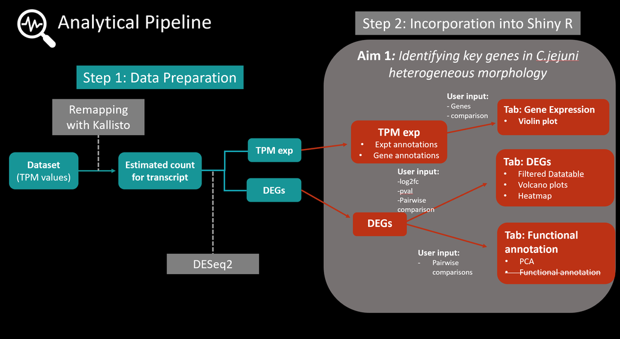

## 2.1 - Acqusition and pseudoalignment of raw reads

We acquired raw reads from experiments that fulfills our research criteria (Spiral / Filamentous morphotypes). In total, 51 *Fastq* files were downloaded from ENA using the L-STRaP-cloud pipeline, limited to the first 1GB of each file. Subsequently, we pseudoaligned the raw RNA-seq reads based on *C.jejuni*([GCA_001877255::ASM187725v1](https://bacteria.ensembl.org/Campylobacter_jejuni_gca_001877255/Info/Index/)) reference transcriptome with *kallisto v0.46.1.50*.

## 2.2 - Functional annotation of aligned reads

Functional annotation of each gene was conducted with *Interproscan v5.51-85.0* to obtain gene ontology terms and gene function predction.

## 2.3 Differential gene expression analysis

Our group utilized the raw read counts obtained from pseudoalignment and conducted differential gene expression analysis using *DESeq2 v1.30.1*. Multi-factorial design was employed to study the effect of strain types and morphology on DGE. Finally, only genes that are differentially expressed were subjected to further analysis .